# Human Activity Recognition

Jan-Peter von Hunnius

Saturday, May 23, 2015

In this data analysis, we try to create a model that can predict how well people perofrm a specifiefd exercise, based on measurements from accelerometers attached to their bodies.

First we read the training and the testing data, which are provided by the website here: http://groupware.les.inf.puc-rio.br/har (explanations can be found in the section on the Weight Lifting Exercise Dataset)

We only take the columns with specified data and filter out columns with too many NA values.

```r
download.file("https://d396qusza40orc.cloudfront.net/predmachlearn/pml-training.csv", "pml-training.csv", method="curl")
download.file("https://d396qusza40orc.cloudfront.net/predmachlearn/pml-testing.csv", "pml-testing.csv", method="curl")

training_set <- read.csv("pml-training.csv", na.strings=c("NA", "#DIV/0!"), stringsAsFactors = FALSE)
testing_set <- read.csv("pml-testing.csv", na.strings=c("NA", "#DIV/0!"), stringsAsFactors = FALSE)

training_set$classe <- as.factor(training_set$classe)

training_NA <- training_set[,colSums(is.na(training_set)) < 1000]
clean_testing <- testing_set[,colSums(is.na(testing_set)) < 1000]

clean_training <- training_NA[,8:60]

rm(training_set)
rm(testing_set)
rm(training_NA)
```

```r
library(caret)
set.seed(0815)

inTrain <- createDataPartition(y = clean_training$classe, p = 0.6, list = FALSE)
training <- clean_training[inTrain,]
validate <- clean_training[-inTrain,]
```

Since the outcome is a category variable, we try to fit models based on trees for prediction. We try a random forest, a bagged trees, and a boosted trees model.

```r
modelRF <- train(classe ~ ., data = training, method="rf")
modelTreeBag <- train(classe ~ ., data = training, method="treebag")
modelGBM <- train(classe ~ ., data = training, method="gbm")
```

[output not shown]

[output cut: 1464 more lines]

[output not shown]

To see how effective the different models can predict, we try them on the validation data.

```r
predictRF <- predict(modelRF, validate)
predictTreeBag <- predict(modelTreeBag, validate)
predictGBM <- predict(modelGBM, validate)

confusionMatrix(predictRF, validate$classe)$overall
```

```
##       Accuracy          Kappa  AccuracyLower  AccuracyUpper   AccuracyNull
##      0.9903135      0.9877449      0.9878907      0.9923608      0.2844762
## AccuracyPValue  McnemarPValue
##      0.0000000            NaN
```

```r
confusionMatrix(predictTreeBag, validate$classe)$overall
```

```
##       Accuracy          Kappa  AccuracyLower  AccuracyUpper   AccuracyNull
##   9.774407e-01   9.714551e-01   9.739084e-01   9.806119e-01   2.844762e-01
## AccuracyPValue  McnemarPValue
##   0.000000e+00   1.157600e-08
```

```r
confusionMatrix(predictGBM, validate$classe)$overall
```

```
##       Accuracy          Kappa  AccuracyLower  AccuracyUpper   AccuracyNull
##   9.609992e-01   9.506543e-01   9.564771e-01   9.651747e-01   2.844762e-01
## AccuracyPValue  McnemarPValue
##   0.000000e+00   1.551461e-06
```

With an accuracy of roughly 99 percent, random forest seems to be the best method to predict activity from the present data set, with tree bags a close second at 98 pecent accuarcy.

Now lets have a look at which recorded data have most impact on the prediction:

```r
varImp(modelRF)
```

```
## rf variable importance
##
##   only 20 most important variables shown (out of 52)
##
##                      Overall
## roll_belt            100.000
## pitch_forearm         56.948
## yaw_belt              48.841
## roll_forearm          42.586
## pitch_belt            42.174
## magnet_dumbbell_y     42.060
## magnet_dumbbell_z     41.501
## accel_dumbbell_y      20.531
## accel_forearm_x       17.547
## roll_dumbbell         16.514
## magnet_dumbbell_x     15.894
## total_accel_dumbbell  14.101
## magnet_belt_z         14.010
## accel_dumbbell_z      13.931
## magnet_forearm_z      13.707
## accel_belt_z          12.932
## magnet_belt_y         12.403
## gyros_belt_z           9.548
## yaw_arm                9.488
## roll_arm               9.379
```

The roll belt and the pitch sensor on the forearm seem to deliver the most influencal data for our prediction. On the graph below, we can see that those two data sources provide a good basis for separation of classe data.

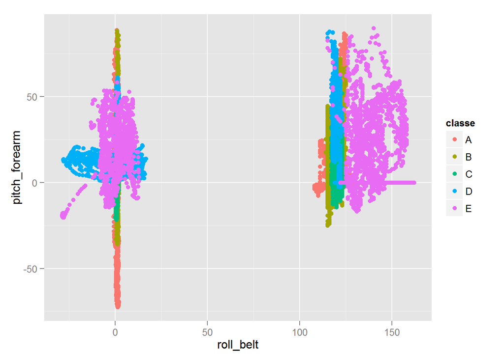

```r
qplot(roll_belt, pitch_forearm, color=classe, data=clean_training)
```

For a last prediction model, we use all three model predictions to build a combined model and analyze its prediction capabilities. The combined model is built using a random forest again.

```r
combinedModelDF <- data.frame(predictRF, predictTreeBag, predictGBM, classe = validate$classe)
modelCombined <- train(classe ~ ., data = combinedModelDF, method="rf")

predictCombined <- predict(modelCombined, combinedModelDF)
confusionMatrix(predictCombined, validate$classe)$overall
```

```
##       Accuracy          Kappa  AccuracyLower  AccuracyUpper   AccuracyNull
##      0.9901861      0.9875838      0.9877493      0.9922475      0.2844762
## AccuracyPValue  McnemarPValue
##      0.0000000            NaN
```

We conclude that the combined model performs a bit worse than the random forest model. Therefore, we construct predictions for the test data set with the random forest model alone.

```r
predict(modelRF, clean_testing)
```

```
##  [1] B A B A A E D B A A B C B A E E A B B B
## Levels: A B C D E
```

We estimate the out of sample error to be 0.0096865 (1 - the accuracy of our model trained with the training data set and validated against the validation data set).